# SHARK TANK INDIA

### IMPORTING LIBRARIES

```python
import pandas as pd
import matplotlib.pyplot as plt
import seaborn as sns
import numpy as np
```

```python
pd.set_option('display.max_columns',None)
```

### IMPORTING DATASET

```python
df=pd.read_csv("C:\\Users\\91934\\OneDrive\\Desktop\\Shark Tank India\\Shark Tank India.csv")
```

```python
df
```

|  | Season Number | Season Start | Season End | Episode Number | Episode Title | Pitch Number | Startup Name | Industry | Business Description | Company Website | Number of Presenters | Male Presenters | Female Presenters | Transgender Presenters | Couple Presenters | Pitchers Average Age | Started in | Pitchers City | Pitchers State | Yearly Revenue | Monthly Sales | Gross Margin | Net Margin | Original Ask Amount | Original Offered Equity | Valuation Requested | Received Offer | Accepted Offer | Total Deal Amount | … |
| --- | --- | --- | --- | --- | --- | --- | --- | --- | --- | --- | --- | --- | --- | --- | --- | --- | --- | --- | --- | --- | --- | --- | --- | --- | --- | --- | --- | --- | --- | --- |
| 0 | 1 | 20-Dec-21 | 4-Feb-22 | 1 | Badlegi Business Ki Tasveer | 1 | BluePineFoods | Food | Frozen Momos | https://bluepinefoods.com/ | 3 | 2.0 | 1.0 | NaN | 0.0 | Middle | 2016.0 | Delhi | Delhi | 95.0 | 8.000 | NaN | NaN | 50.00000 | 5.00 | 1000.000000 | 1 | 1.0 | 75.00000 | … |
| 1 | 1 | 20-Dec-21 | 4-Feb-22 | 1 | Badlegi Business Ki Tasveer | 2 | BoozScooters | Vehicles/Electrical Vehicles | Renting e-bike for mobility in private spaces | https://www.boozup.net/ | 1 | 1.0 | NaN | NaN | 0.0 | Young | 2017.0 | Ahmedabad | Gujarat | 4.0 | 0.400 | NaN | NaN | 40.00000 | 15.00 | 267.000000 | 1 | 1.0 | 40.00000 | … |
| 2 | 1 | 20-Dec-21 | 4-Feb-22 | 1 | Badlegi Business Ki Tasveer | 3 | HeartUpMySleeves | Beauty/Fashion | Detachable Sleeves | https://heartupmysleeves.com/ | 1 | NaN | 1.0 | NaN | 0.0 | Young | 2021.0 | Delhi | Delhi | NaN | 2.000 | NaN | NaN | 25.00000 | 10.00 | 250.000000 | 1 | 1.0 | 25.00000 | … |
| 3 | 1 | 20-Dec-21 | 4-Feb-22 | 2 | Insaan, Ideas Aur Sapne | 4 | TagzFoods | Food | Healthy Potato Chips Snacks | https://tagzfoods.com/ | 2 | 2.0 | NaN | NaN | 0.0 | Middle | 2019.0 | Bangalore | Karnataka | 700.0 | NaN | 48.0 | NaN | 70.00000 | 1.00 | 7000.000000 | 1 | 1.0 | 70.00000 | … |
| 4 | 1 | 20-Dec-21 | 4-Feb-22 | 2 | Insaan, Ideas Aur Sapne | 5 | HeadAndHeart | Education | Brain Development Course | https://thehnh.in/ | 4 | 1.0 | 3.0 | NaN | 1.0 | Middle | 2015.0 | Patiala | Punjab | 30.0 | NaN | NaN | NaN | 50.00000 | 5.00 | 1000.000000 | 0 | NaN | NaN | … |
| 5 | 1 | 20-Dec-21 | 4-Feb-22 | 2 | Insaan, Ideas Aur Sapne | 6 | Agritourism | Agriculture | Tourism | https://www.agritourism.in/ | 2 | 1.0 | 1.0 | NaN | 1.0 | Middle | 2005.0 | Baramati | Maharashtra | 79.0 | NaN | NaN | NaN | 50.00000 | 5.00 | 1000.000000 | 0 | NaN | NaN | … |
| 6 | 1 | 20-Dec-21 | 4-Feb-22 | 3 | Aam Aadmi Ke Business Ideas | 7 | qZenseLabs | Food | Food Freshness Detector | https://www.qzense.com/ | 2 | NaN | 2.0 | NaN | 0.0 | Middle | 2020.0 | Delhi,Mohali | Delhi,Punjab | 25.0 | NaN | NaN | NaN | 100.00000 | 0.25 | 40000.000000 | 1 | 0.0 | NaN | … |
| 7 | 1 | 20-Dec-21 | 4-Feb-22 | 3 | Aam Aadmi Ke Business Ideas | 8 | Peeschute | Beauty/Fashion | Disposable Urine Bag | https://www.peeschute.com/ | 1 | 1.0 | NaN | NaN | 0.0 | Young | 2019.0 | Jalna | Maharashtra | 100.0 | NaN | NaN | NaN | 75.00000 | 4.00 | 1875.000000 | 1 | 1.0 | 75.00000 | … |
| 8 | 1 | 20-Dec-21 | 4-Feb-22 | 3 | Aam Aadmi Ke Business Ideas | 9 | NOCD | Food | Energy Drink | https://www.jouleshealth.com/ | 2 | 2.0 | NaN | NaN | 0.0 | Middle | 2019.0 | Bangalore | Karnataka | NaN | 20.000 | NaN | NaN | 50.00000 | 2.00 | 2500.000000 | 1 | 1.0 | 20.00000 | … |
| 9 | 1 | 20-Dec-21 | 4-Feb-22 | 4 | Entrepreneurship Ki Wave | 10 | CosIQ | Beauty/Fashion | Intelligent Skincare | https://mycosiq.com/ | 2 | 1.0 | 1.0 | NaN | 1.0 | Middle | 2021.0 | Delhi | Delhi | NaN | 4.000 | 75.0 | NaN | 50.00000 | 7.50 | 667.000000 | 1 | 1.0 | 50.00000 | … |
| 10 | 1 | 20-Dec-21 | 4-Feb-22 | 4 | Entrepreneurship Ki Wave | 11 | JhaJiAchaar | Food | Pickle | https://www.jhajistore.com/ | 2 | NaN | 2.0 | NaN | 0.0 | Old | 2021.0 | Darbhanga | Bihar | NaN | 5.000 | 18.0 | NaN | 50.00000 | 10.00 | 500.000000 | 1 | 1.0 | 56.60000 | … |
| 11 | 1 | 20-Dec-21 | 4-Feb-22 | 4 | Entrepreneurship Ki Wave | 12 | Bummer | Beauty/Fashion | Underwear | https://bummer.in/ | 1 | 1.0 | NaN | NaN | 0.0 | Young | 2020.0 | Ahmedabad | Gujarat | NaN | 15.000 | 70.0 | NaN | 75.00000 | 4.00 | 1875.000000 | 1 | 1.0 | 75.00000 | … |
| 12 | 1 | 20-Dec-21 | 4-Feb-22 | 5 | Hunt For Interesting Business | 13 | RevampMoto | Vehicles/Electrical Vehicles | E-Bike Mitra bud-e RM | https://www.revampmoto.in/ | 3 | 3.0 | NaN | NaN | 0.0 | Young | NaN | Nashik | Maharashtra | NaN | 0.010 | NaN | NaN | 100.00000 | 1.00 | 10000.000000 | 1 | 1.0 | 100.00000 | … |
| 13 | 1 | 20-Dec-21 | 4-Feb-22 | 5 | Hunt For Interesting Business | 14 | HungryHead | Food | Restaurant serving 80 types of Maggi | http://www.hungryhead.co.in/ | 2 | 2.0 | NaN | NaN | 0.0 | Middle | 2013.0 | Mumbai | Maharashtra | NaN | 5.500 | NaN | NaN | 50.00000 | 5.00 | 1000.000000 | 0 | NaN | NaN | … |
| 14 | 1 | 20-Dec-21 | 4-Feb-22 | 5 | Hunt For Interesting Business | 15 | ShrawaniEngineers | Beauty/Fashion | Belly Button Shaper | https://www.shrawaniengineers.com/ | 2 | 1.0 | 1.0 | NaN | 1.0 | Middle | 2019.0 | Nagpur | Maharashtra | 50.0 | NaN | NaN | NaN | 20.00000 | 10.00 | 200.000000 | 0 | NaN | NaN | … |
| 15 | 1 | 20-Dec-21 | 4-Feb-22 | 6 | New Week, New Ideas | 16 | SkippiIcePops | Food | Ice-Pops | https://skippi.in/ | 2 | 1.0 | 1.0 | NaN | 1.0 | Middle | NaN | Hyderabad | Telangana | NaN | 6.000 | NaN | NaN | 45.00000 | 5.00 | 900.000000 | 1 | 1.0 | 100.00000 | … |
| 16 | 1 | 20-Dec-21 | 4-Feb-22 | 6 | New Week, New Ideas | 17 | Menstrupedia | Education | Menstrual Awareness Comic | https://www.menstrupedia.com/ | 2 | 1.0 | 1.0 | NaN | 1.0 | Middle | NaN | Ahmedabad | Gujarat | 115.0 | NaN | NaN | NaN | 50.00000 | 10.00 | 500.000000 | 1 | 1.0 | 50.00000 | … |
| 17 | 1 | 20-Dec-21 | 4-Feb-22 | 6 | New Week, New Ideas | 18 | Hecoll | Beauty/Fashion | Pollution Resistant Fabric - Healthy Cover For... | https://hecoll.com/ | 1 | NaN | 1.0 | NaN | 0.0 | Middle | 2019.0 | Hyderabad | Telangana | 107.0 | NaN | NaN | NaN | 100.00000 | 1.00 | 10000.000000 | 0 | NaN | NaN | … |
| 18 | 1 | 20-Dec-21 | 4-Feb-22 | 7 | A Never Give Up Spirit | 19 | RaisingSuperstars | Education | Child Development App | https://raisingsuperstars.com/india-page | 2 | 1.0 | 1.0 | NaN | 1.0 | Middle | 2020.0 | Gurgaon | Haryana | 1300.0 | NaN | NaN | NaN | 100.00000 | 2.00 | 5000.000000 | 1 | 1.0 | 100.00000 | … |
| 19 | 1 | 20-Dec-21 | 4-Feb-22 | 7 | A Never Give Up Spirit | 20 | Torch-it | Education | Gadgets for visually impaired people | https://mytorchit.com/ | 1 | 1.0 | NaN | NaN | 0.0 | Middle | 2018.0 | Ahmedabad | Gujarat | NaN | 1.000 | NaN | NaN | 75.00000 | 1.00 | 7500.000000 | 1 | 0.0 | NaN | … |
| 20 | 1 | 20-Dec-21 | 4-Feb-22 | 7 | A Never Give Up Spirit | 21 | Kavach | Education | Report bullying incidents | NaN | 2 | 1.0 | 1.0 | NaN | NaN | Young | NaN | Gurgaon | Haryana | NaN | NaN | NaN | NaN | 5.00000 | 10.00 | 50.000000 | 1 | 1.0 | 5.00000 | … |
| 21 | 1 | 20-Dec-21 | 4-Feb-22 | 7 | A Never Give Up Spirit | 22 | LaKheerDeli | Food | Kheer in variety of flavors | https://lakheerdeli.com/ | 3 | 1.0 | 2.0 | NaN | 0.0 | Middle | NaN | Pune | Maharashtra | NaN | 6.000 | NaN | NaN | 50.00000 | 7.50 | 667.000000 | 1 | 0.0 | NaN | … |
| 22 | 1 | 20-Dec-21 | 4-Feb-22 | 8 | Shark Ko Impress Karne Wale Ideas | 23 | BeyondSnack | Food | Kerala Banana Chips | https://www.beyondsnack.in/ | 1 | 1.0 | NaN | NaN | 0.0 | Middle | NaN | Thiruvananthapuram | Kerala | NaN | 20.600 | 51.0 | NaN | 50.00000 | 2.50 | 2000.000000 | 1 | 1.0 | 50.00000 | … |
| 23 | 1 | 20-Dec-21 | 4-Feb-22 | 8 | Shark Ko Impress Karne Wale Ideas | 24 | VivalyfInnovations | Medical/Health | Easy Life Prickless Diabetes Testing Machine | https://vivalyf.in/ | 2 | 1.0 | 1.0 | NaN | 0.0 | Young | NaN | Hyderabad | Telangana | NaN | NaN | NaN | NaN | 56.00000 | 7.50 | 747.000000 | 1 | 1.0 | 56.00000 | … |
| 24 | 1 | 20-Dec-21 | 4-Feb-22 | 8 | Shark Ko Impress Karne Wale Ideas | 25 | MotionBreeze | Vehicles/Electrical Vehicles | Smart Electric Motorcycle | https://www.motionautomotive.in/ | 4 | 4.0 | NaN | NaN | 0.0 | Middle | NaN | Vadodara | Gujarat | 0.0 | NaN | NaN | NaN | 30.00000 | 3.00 | 1000.000000 | 1 | 1.0 | 30.00000 | … |
| 25 | 1 | 20-Dec-21 | 4-Feb-22 | 9 | Defining Innovations | 26 | Altor | Manufacturing | Smart Helmets | https://www.altorsmarthelmet.com/ | 4 | 4.0 | NaN | NaN | 0.0 | Young | 2019.0 | Kolkata | West Bengal | NaN | NaN | NaN | NaN | 50.00000 | 5.00 | 1000.000000 | 1 | 1.0 | 50.00000 | … |
| 26 | 1 | 20-Dec-21 | 4-Feb-22 | 9 | Defining Innovations | 27 | Ariro | Manufacturing | Wooden Toys | https://arirotoys.com/ | 2 | 1.0 | 1.0 | NaN | 1.0 | Young | 2020.0 | Chennai | Tamil Nadu | 300.0 | 25.000 | 50.0 | NaN | 50.00000 | 2.50 | 2000.000000 | 1 | 1.0 | 50.00000 | … |
| 27 | 1 | 20-Dec-21 | 4-Feb-22 | 9 | Defining Innovations | 28 | KabiraHandmad | Food | Healthy Edible Oils dairy products spices flour | https://www.kabirafoods.com/ | 2 | 1.0 | 1.0 | NaN | 1.0 | Middle | NaN | Jaipur | Rajasthan | NaN | 160.000 | 3.0 | NaN | 100.00000 | 5.00 | 2000.000000 | 1 | 0.0 | NaN | … |
| 28 | 1 | 20-Dec-21 | 4-Feb-22 | 10 | Passion About Entrepreneurship | 29 | Nuutjob | Beauty/Fashion | Male Intimate Hygiene deo spray | https://nuutjob.com/ | 2 | NaN | 2.0 | NaN | 0.0 | Young | 2021.0 | Ahmedabad | Gujarat | NaN | 0.002 | 70.0 | NaN | 25.00000 | 5.00 | 500.000000 | 1 | 1.0 | 25.00000 | … |
| 29 | 1 | 20-Dec-21 | 4-Feb-22 | 10 | Passion About Entrepreneurship | 30 | Meatyour | Food | Eggs | https://meatyour.com/ | 3 | 3.0 | NaN | NaN | 0.0 | Middle | NaN | Pune | Maharashtra | 130.0 | 2.800 | 30.0 | NaN | 30.00000 | 5.00 | 600.000000 | 1 | 1.0 | 30.00000 | … |

[output cut: 290 more lines]

## SHARK TANK INDIA DATA SET DESCRIPTION

Shark Tank India - Season 1 and Season 2 information, with 64 fields/columns and 320+ records.

Here is the data dictionary for the Shark Tank (India) season dataset.

Season Number - Season number

Season Start - Season first aired date

Season End - Season last aired date

Episode Number - Episode number within the season

Episode Title - Episode title in SonyLiv

Pitch Number - Overall pitch number

Startup Name - Startup company name

Industry - Industry name or type

Business Description - Business Description

Company Website - Company Website URL

Number of Presenters - Number of presenters

Male Presenters - Number of male presenters

Female Presenters - Number of female presenters

Transgender Presenters - Number of transgender/LGBTQ presenters

Couple Presenters - Are the presenter's wife/husband? 1-yes, 0-no

Pitchers Average Age - Pitchers average age, <30 young, 30-50 middle, >50 old

Started in the year in which the startup was started/incorporated

Pitchers City - Presenter's town/city

Pitchers State - Indian state pitcher hails from

Yearly Revenue - Yearly revenue, in lakhs INR, -1 means negative revenue, 0 means pre-revenue

Monthly Sales - Total monthly sales, in lakhs

Gross Margin - Gross margin/profit of company, in percentages

Net Margin - Net margin/profit of company, in percentages

Original Ask Amount - Original Ask Amount, in lakhs INR

Original Offered Equity - Original Offered Equity, in percentages

Valuation Requested - Valuation Requested, in lakhs INR

Received Offer - Received offer or not, 1-received, 0-not received

Accepted Offer - Accepted offer or not, 1-accepted, 0-rejected

Total Deal Amount - Total Deal Amount, in lakhs INR

Total Deal Equity - Total Deal Equity, in percentages

Total Deal Debt - Total Deal Debt, in lakhs INR

Debt Interest - Debt interest rate, in percentages

Deal Valuation - Deal Valuation, in lakhs INR

Number of sharks in the deal - Number of sharks involved in the deal

The deal has conditions - Do the deals have any constraints or not?

Has Patents - Pitcher has Patents? 1-yes, 0-no

Ashneer Investment Amount - Ashneer Investment Amount, in lakhs INR

Ashneer Investment Equity - Ashneer Investment Equity, in percentages

Ashneer Debt Amount - Ashneer Debt Amount, in lakhs INR

Namita Investment Amount - Namita Investment Amount, in lakhs INR

Namita Investment Equity - Namita Investment Equity, in percentages

Namita Debt Amount - Namita Debt Amount, in lakhs INR

Anupam Investment Amount - Anupam Investment Amount, in lakhs INR

Anupam Investment Equity - Anupam Investment Equity, in percentages

Anupam Debt Amount - Anupam Debt Amount, in lakhs INR

Vineeta Investment Amount - Vineeta Investment Amount, in lakhs INR

Vineeta Investment Equity - Vineeta Investment Equity, in percentages

Vineeta Debt Amount - Vineeta Debt Amount, in lakhs INR

Aman Investment Amount - Aman Investment Amount, in lakhs INR

Aman Investment Equity - Aman Investment Equity, in percentages

Aman Debt Amount - Aman Debt Amount, in lakhs INR

Peyush Investment Amount - Peyush Investment Amount, in lakhs INR

Peyush Investment Equity - Peyush Investment Equity, in percentages

Peyush Debt Amount - Peyush Debt Amount, in lakhs INR

Ghazal Investment Amount - Ghazal Investment Amount, in lakhs INR

Ghazal Investment Equity - Ghazal Investment Equity, in percentages

Ghazal Debt Amount - Ghazal Debt Amount, in lakhs INR

Amit Investment Amount - Amit Investment Amount, in lakhs INR

Amit Investment Equity - Amit Investment Equity, in percentages

Amit Debt Amount - Amit Debt Amount, in lakhs INR

Guest Investment Amount - Guest Investment Amount, in lakhs INR

Guest Investment Equity - Guest Investment Equity, in percentages

Guest Debt Amount - Guest Debt Amount, in lakhs INR

Guest Name - Name of Guest

### NATURE OF THE DATASET

```python
print("Dataset contains", df.shape[0], "samples and" , df.shape[1], "features")
```

```
Dataset contains 320 samples and 64 features
```

### DATASET ATTRIBUTES

```python
df.columns
```

```
Index(['Season Number', 'Season Start', 'Season End', 'Episode Number',
       'Episode Title', 'Pitch Number', 'Startup Name', 'Industry',
       'Business Description', 'Company Website', 'Number of Presenters',
       'Male Presenters', 'Female Presenters', 'Transgender Presenters',
       'Couple Presenters', 'Pitchers Average Age', 'Started in',
       'Pitchers City', 'Pitchers State', 'Yearly Revenue', 'Monthly Sales',
       'Gross Margin', 'Net Margin', 'Original Ask Amount',
       'Original Offered Equity', 'Valuation Requested', 'Received Offer',
       'Accepted Offer', 'Total Deal Amount', 'Total Deal Equity',
       'Total Deal Debt', 'Debt Interest', 'Deal Valuation',
       'Number of sharks in deal', 'Deal has conditions', 'Has Patents',
       'Ashneer Investment Amount', 'Ashneer Investment Equity',
       'Ashneer Debt Amount', 'Namita Investment Amount',
       'Namita Investment Equity', 'Namita Debt Amount',
       'Anupam Investment Amount', 'Anupam Investment Equity',
       'Anupam Debt Amount', 'Vineeta Investment Amount',
       'Vineeta Investment Equity', 'Vineeta Debt Amount',
       'Aman Investment Amount', 'Aman Investment Equity', 'Aman Debt Amount',
       'Peyush Investment Amount', 'Peyush Investment Equity',
       'Peyush Debt Amount', 'Ghazal Investment Amount',
       'Ghazal Investment Equity', 'Ghazal Debt Amount',
       'Amit Investment Amount', 'Amit Investment Equity', 'Amit Debt Amount',
       'Guest Investment Amount', 'Guest Investment Equity',
       'Guest Debt Amount', 'Guest Name'],
      dtype='object')
```

### STATISTICAL OVERVIEW

```python
df.head()
```

|  | Season Number | Season Start | Season End | Episode Number | Episode Title | Pitch Number | Startup Name | Industry | Business Description | Company Website | Number of Presenters | Male Presenters | Female Presenters | Transgender Presenters | Couple Presenters | Pitchers Average Age | Started in | Pitchers City | Pitchers State | Yearly Revenue | Monthly Sales | Gross Margin | Net Margin | Original Ask Amount | Original Offered Equity | Valuation Requested | Received Offer | Accepted Offer | Total Deal Amount | … |
| --- | --- | --- | --- | --- | --- | --- | --- | --- | --- | --- | --- | --- | --- | --- | --- | --- | --- | --- | --- | --- | --- | --- | --- | --- | --- | --- | --- | --- | --- | --- |
| 0 | 1 | 20-Dec-21 | 4-Feb-22 | 1 | Badlegi Business Ki Tasveer | 1 | BluePineFoods | Food | Frozen Momos | https://bluepinefoods.com/ | 3 | 2.0 | 1.0 | NaN | 0.0 | Middle | 2016.0 | Delhi | Delhi | 95.0 | 8.0 | NaN | NaN | 50.0 | 5.0 | 1000.0 | 1 | 1.0 | 75.0 | … |
| 1 | 1 | 20-Dec-21 | 4-Feb-22 | 1 | Badlegi Business Ki Tasveer | 2 | BoozScooters | Vehicles/Electrical Vehicles | Renting e-bike for mobility in private spaces | https://www.boozup.net/ | 1 | 1.0 | NaN | NaN | 0.0 | Young | 2017.0 | Ahmedabad | Gujarat | 4.0 | 0.4 | NaN | NaN | 40.0 | 15.0 | 267.0 | 1 | 1.0 | 40.0 | … |
| 2 | 1 | 20-Dec-21 | 4-Feb-22 | 1 | Badlegi Business Ki Tasveer | 3 | HeartUpMySleeves | Beauty/Fashion | Detachable Sleeves | https://heartupmysleeves.com/ | 1 | NaN | 1.0 | NaN | 0.0 | Young | 2021.0 | Delhi | Delhi | NaN | 2.0 | NaN | NaN | 25.0 | 10.0 | 250.0 | 1 | 1.0 | 25.0 | … |
| 3 | 1 | 20-Dec-21 | 4-Feb-22 | 2 | Insaan, Ideas Aur Sapne | 4 | TagzFoods | Food | Healthy Potato Chips Snacks | https://tagzfoods.com/ | 2 | 2.0 | NaN | NaN | 0.0 | Middle | 2019.0 | Bangalore | Karnataka | 700.0 | NaN | 48.0 | NaN | 70.0 | 1.0 | 7000.0 | 1 | 1.0 | 70.0 | … |
| 4 | 1 | 20-Dec-21 | 4-Feb-22 | 2 | Insaan, Ideas Aur Sapne | 5 | HeadAndHeart | Education | Brain Development Course | https://thehnh.in/ | 4 | 1.0 | 3.0 | NaN | 1.0 | Middle | 2015.0 | Patiala | Punjab | 30.0 | NaN | NaN | NaN | 50.0 | 5.0 | 1000.0 | 0 | NaN | NaN | … |

```python
df.tail()
```

|  | Season Number | Season Start | Season End | Episode Number | Episode Title | Pitch Number | Startup Name | Industry | Business Description | Company Website | Number of Presenters | Male Presenters | Female Presenters | Transgender Presenters | Couple Presenters | Pitchers Average Age | Started in | Pitchers City | Pitchers State | Yearly Revenue | Monthly Sales | Gross Margin | Net Margin | Original Ask Amount | Original Offered Equity | Valuation Requested | Received Offer | Accepted Offer | Total Deal Amount | … |
| --- | --- | --- | --- | --- | --- | --- | --- | --- | --- | --- | --- | --- | --- | --- | --- | --- | --- | --- | --- | --- | --- | --- | --- | --- | --- | --- | --- | --- | --- | --- |
| 315 | 2 | 2-Jan-23 | 10-Mar-23 | 50 | Season Finale With The Sharks | 316 | MYBYK | Vehicles/Electrical Vehicles | IoT-enabled bikes | https://mybyk.in/ | 1 | 1.0 | NaN | NaN | 0.0 | Middle | NaN | Ahmedabad | Gujarat | -1.0 | NaN | NaN | NaN | 200.0 | 1.0 | 20000.0 | 0 | NaN | NaN | … |
| 316 | 2 | 2-Jan-23 | 10-Mar-23 | 51 | Gateway To Shark Tank India | 317 | GODESi | Food | Handmade lollipops | https://godesi.in/ | 2 | 1.0 | 1.0 | NaN | 0.0 | Middle | NaN | Bangalore | Karnataka | -1.0 | 270.0 | NaN | NaN | 90.0 | 0.5 | 18000.0 | 1 | 0.0 | NaN | … |
| 317 | 2 | 2-Jan-23 | 10-Mar-23 | 51 | Gateway To Shark Tank India | 318 | TAC | Beauty/Fashion | ayurveda co for glowing skin, makeup & open pores | https://theayurvedaco.com/ | 2 | 1.0 | 1.0 | NaN | 1.0 | Middle | NaN | Mumbai | Maharashtra | -1.0 | NaN | NaN | NaN | 150.0 | 0.5 | 30000.0 | 1 | 1.0 | 81.0 | … |
| 318 | 2 | 2-Jan-23 | 10-Mar-23 | 51 | Gateway To Shark Tank India | 319 | Naara-Aaba | Liquor/Beverages | pears and plum wine | https://www.naaraaaba.com/ | 2 | 1.0 | 1.0 | NaN | 1.0 | Middle | 2017.0 | Ziro | Arunachal Pradesh | NaN | NaN | 50.0 | 18.0 | 75.0 | 2.5 | 3000.0 | 1 | 1.0 | 50.0 | … |
| 319 | 2 | 2-Jan-23 | 10-Mar-23 | 51 | Gateway To Shark Tank India | 320 | StyloBug | Beauty/Fashion | Girls Dresses Online | https://stylobug.com/ | 2 | 1.0 | 1.0 | NaN | NaN | Middle | NaN | Delhi | Delhi | 1400.0 | 46.0 | NaN | 18.0 | 80.0 | 2.0 | 4000.0 | 1 | 1.0 | 80.0 | … |

```python
df.info()
```

```
<class 'pandas.core.frame.DataFrame'>
RangeIndex: 320 entries, 0 to 319
Data columns (total 64 columns):
 #   Column                     Non-Null Count  Dtype
---  ------                     --------------  -----
 0   Season Number              320 non-null    int64
 1   Season Start               320 non-null    object
 2   Season End                 320 non-null    object
 3   Episode Number             320 non-null    int64
 4   Episode Title              320 non-null    object
 5   Pitch Number               320 non-null    int64
 6   Startup Name               320 non-null    object
 7   Industry                   320 non-null    object
 8   Business Description       320 non-null    object
 9   Company Website            309 non-null    object
```

[output cut: 56 more lines]

### OBSERVATION :

1. The column types are mixed types such as float, object and an int.
2. Columns name stated in indicates startup year that should not be in float.
3. So we have to convert them into int columns named Patents, Male Presenters, Female Presenters, Transgender Presenters, and Couple Presenters should not be in float, so we have to convert them into an int.
4. Some columns have missing values.
5. Columns of the float type: 47
6. Columns of the int type: 5
7. Columns of the object type: 12
8. Memory occupied by this data set: 160.1 kB.

```python
df.describe()
```

|  | Season Number | Episode Number | Pitch Number | Number of Presenters | Male Presenters | Female Presenters | Transgender Presenters | Couple Presenters | Started in | Yearly Revenue | Monthly Sales | Gross Margin | Net Margin | Original Ask Amount | Original Offered Equity | Valuation Requested | Received Offer | Accepted Offer | Total Deal Amount | Total Deal Equity | Total Deal Debt | Debt Interest | Deal Valuation | Number of sharks in deal | Has Patents | Ashneer Investment Amount | Ashneer Investment Equity | Ashneer Debt Amount | Namita Investment Amount | … |
| --- | --- | --- | --- | --- | --- | --- | --- | --- | --- | --- | --- | --- | --- | --- | --- | --- | --- | --- | --- | --- | --- | --- | --- | --- | --- | --- | --- | --- | --- | --- |
| count | 320.000000 | 320.000000 | 320.000000 | 320.000000 | 281.000000 | 149.000000 | 3.0 | 315.000000 | 184.000000 | 134.000000 | 140.000000 | 85.000000 | 24.000000 | 320.000000 | 320.000000 | 320.000000 | 320.000000 | 216.000000 | 176.000000 | 176.000000 | 39.000000 | 23.000000 | 176.000000 | 176.000000 | 7.0 | 21.000000 | 21.000000 | 2.00000 | 66.000000 | … |
| mean | 1.525000 | 21.550000 | 160.500000 | 2.078125 | 1.722420 | 1.194631 | 1.0 | 0.187302 | 2018.472826 | 355.947761 | 42.342514 | 53.494118 | 23.500000 | 168.878128 | 4.085906 | 5105.203751 | 0.675000 | 0.814815 | 62.531824 | 10.169432 | 46.435897 | 10.260870 | 1782.786824 | 2.011364 | 1.0 | 25.682381 | 4.440000 | 57.00000 | 31.780459 | … |
| std | 0.500157 | 14.676362 | 92.520268 | 0.847358 | 0.866744 | 0.429925 | 0.0 | 0.390774 | 2.495750 | 918.888781 | 90.427172 | 22.593522 | 10.615821 | 1674.190451 | 3.626253 | 9902.277748 | 0.469108 | 0.389350 | 36.267912 | 10.640055 | 27.782799 | 3.683099 | 2831.961861 | 1.126251 | 0.0 | 16.860620 | 5.065662 | 59.39697 | 19.778840 | … |
| min | 1.000000 | 0.000000 | 1.000000 | 1.000000 | 1.000000 | 1.000000 | 1.0 | 0.000000 | 2005.000000 | -1.000000 | 0.000000 | 3.000000 | 3.000000 | 0.000000 | 0.200000 | 0.000000 | 0.000000 | 0.000000 | 0.000000 | 0.500000 | 20.000000 | 0.000000 | 0.000000 | 1.000000 | 1.0 | 1.000000 | 1.000000 | 15.00000 | 0.000016 | … |
| 25% | 1.000000 | 9.000000 | 80.750000 | 2.000000 | 1.000000 | 1.000000 | 1.0 | 0.000000 | 2017.000000 | 0.000000 | 3.500000 | 40.000000 | 18.000000 | 50.000000 | 1.500000 | 1000.000000 | 0.000000 | 1.000000 | 40.000000 | 3.000000 | 25.000000 | 10.000000 | 324.750000 | 1.000000 | 1.0 | 15.000000 | 2.000000 | 36.00000 | 19.250000 | … |
| 50% | 2.000000 | 21.000000 | 160.500000 | 2.000000 | 2.000000 | 1.000000 | 1.0 | 0.000000 | 2019.000000 | 100.000000 | 14.000000 | 51.000000 | 22.500000 | 62.500000 | 3.000000 | 2000.000000 | 1.000000 | 1.000000 | 50.000000 | 6.000000 | 41.000000 | 10.000000 | 1000.000000 | 2.000000 | 1.0 | 20.000000 | 3.000000 | 57.00000 | 25.830000 | … |
| 75% | 2.000000 | 33.000000 | 240.250000 | 2.000000 | 2.000000 | 1.000000 | 1.0 | 0.000000 | 2020.000000 | 247.500000 | 33.000000 | 69.000000 | 31.250000 | 100.000000 | 5.000000 | 5000.000000 | 1.000000 | 1.000000 | 80.000000 | 15.000000 | 50.000000 | 12.000000 | 2000.000000 | 3.000000 | 1.0 | 30.000000 | 5.000000 | 78.00000 | 43.750000 | … |
| max | 2.000000 | 51.000000 | 320.000000 | 6.000000 | 6.000000 | 3.000000 | 1.0 | 1.000000 | 2022.000000 | 7200.000000 | 700.000000 | 150.000000 | 40.000000 | 30000.000000 | 25.000000 | 120000.000000 | 1.000000 | 1.000000 | 200.000000 | 75.000000 | 150.000000 | 18.000000 | 25000.000000 | 5.000000 | 1.0 | 70.000000 | 25.000000 | 99.00000 | 100.000000 | … |

### CHECKING NULL VALUES

```python
df.isnull()
```

|  | Season Number | Season Start | Season End | Episode Number | Episode Title | Pitch Number | Startup Name | Industry | Business Description | Company Website | Number of Presenters | Male Presenters | Female Presenters | Transgender Presenters | Couple Presenters | Pitchers Average Age | Started in | Pitchers City | Pitchers State | Yearly Revenue | Monthly Sales | Gross Margin | Net Margin | Original Ask Amount | Original Offered Equity | Valuation Requested | Received Offer | Accepted Offer | Total Deal Amount | … |
| --- | --- | --- | --- | --- | --- | --- | --- | --- | --- | --- | --- | --- | --- | --- | --- | --- | --- | --- | --- | --- | --- | --- | --- | --- | --- | --- | --- | --- | --- | --- |
| 0 | False | False | False | False | False | False | False | False | False | False | False | False | False | True | False | False | False | False | False | False | False | True | True | False | False | False | False | False | False | … |
| 1 | False | False | False | False | False | False | False | False | False | False | False | False | True | True | False | False | False | False | False | False | False | True | True | False | False | False | False | False | False | … |
| 2 | False | False | False | False | False | False | False | False | False | False | False | True | False | True | False | False | False | False | False | True | False | True | True | False | False | False | False | False | False | … |
| 3 | False | False | False | False | False | False | False | False | False | False | False | False | True | True | False | False | False | False | False | False | True | False | True | False | False | False | False | False | False | … |
| 4 | False | False | False | False | False | False | False | False | False | False | False | False | False | True | False | False | False | False | False | False | True | True | True | False | False | False | False | True | True | … |
| 5 | False | False | False | False | False | False | False | False | False | False | False | False | False | True | False | False | False | False | False | False | True | True | True | False | False | False | False | True | True | … |
| 6 | False | False | False | False | False | False | False | False | False | False | False | True | False | True | False | False | False | False | False | False | True | True | True | False | False | False | False | False | True | … |
| 7 | False | False | False | False | False | False | False | False | False | False | False | False | True | True | False | False | False | False | False | False | True | True | True | False | False | False | False | False | False | … |
| 8 | False | False | False | False | False | False | False | False | False | False | False | False | True | True | False | False | False | False | False | True | False | True | True | False | False | False | False | False | False | … |
| 9 | False | False | False | False | False | False | False | False | False | False | False | False | False | True | False | False | False | False | False | True | False | False | True | False | False | False | False | False | False | … |
| 10 | False | False | False | False | False | False | False | False | False | False | False | True | False | True | False | False | False | False | False | True | False | False | True | False | False | False | False | False | False | … |
| 11 | False | False | False | False | False | False | False | False | False | False | False | False | True | True | False | False | False | False | False | True | False | False | True | False | False | False | False | False | False | … |
| 12 | False | False | False | False | False | False | False | False | False | False | False | False | True | True | False | False | True | False | False | True | False | True | True | False | False | False | False | False | False | … |
| 13 | False | False | False | False | False | False | False | False | False | False | False | False | True | True | False | False | False | False | False | True | False | True | True | False | False | False | False | True | True | … |
| 14 | False | False | False | False | False | False | False | False | False | False | False | False | False | True | False | False | False | False | False | False | True | True | True | False | False | False | False | True | True | … |
| 15 | False | False | False | False | False | False | False | False | False | False | False | False | False | True | False | False | True | False | False | True | False | True | True | False | False | False | False | False | False | … |
| 16 | False | False | False | False | False | False | False | False | False | False | False | False | False | True | False | False | True | False | False | False | True | True | True | False | False | False | False | False | False | … |
| 17 | False | False | False | False | False | False | False | False | False | False | False | True | False | True | False | False | False | False | False | False | True | True | True | False | False | False | False | True | True | … |
| 18 | False | False | False | False | False | False | False | False | False | False | False | False | False | True | False | False | False | False | False | False | True | True | True | False | False | False | False | False | False | … |
| 19 | False | False | False | False | False | False | False | False | False | False | False | False | True | True | False | False | False | False | False | True | False | True | True | False | False | False | False | False | True | … |
| 20 | False | False | False | False | False | False | False | False | False | True | False | False | False | True | True | False | True | False | False | True | True | True | True | False | False | False | False | False | False | … |
| 21 | False | False | False | False | False | False | False | False | False | False | False | False | False | True | False | False | True | False | False | True | False | True | True | False | False | False | False | False | True | … |
| 22 | False | False | False | False | False | False | False | False | False | False | False | False | True | True | False | False | True | False | False | True | False | False | True | False | False | False | False | False | False | … |
| 23 | False | False | False | False | False | False | False | False | False | False | False | False | False | True | False | False | True | False | False | True | True | True | True | False | False | False | False | False | False | … |
| 24 | False | False | False | False | False | False | False | False | False | False | False | False | True | True | False | False | True | False | False | False | True | True | True | False | False | False | False | False | False | … |
| 25 | False | False | False | False | False | False | False | False | False | False | False | False | True | True | False | False | False | False | False | True | True | True | True | False | False | False | False | False | False | … |
| 26 | False | False | False | False | False | False | False | False | False | False | False | False | False | True | False | False | False | False | False | False | False | False | True | False | False | False | False | False | False | … |
| 27 | False | False | False | False | False | False | False | False | False | False | False | False | False | True | False | False | True | False | False | True | False | False | True | False | False | False | False | False | True | … |
| 28 | False | False | False | False | False | False | False | False | False | False | False | True | False | True | False | False | False | False | False | True | False | False | True | False | False | False | False | False | False | … |
| 29 | False | False | False | False | False | False | False | False | False | False | False | False | True | True | False | False | True | False | False | False | False | False | True | False | False | False | False | False | False | … |

[output cut: 290 more lines]

```python
pd.set_option('display.max_columns',None)
```

```python
df.isnull().sum()
```

```
Season Number                  0
Season Start                   0
Season End                     0
Episode Number                 0
Episode Title                  0
Pitch Number                   0
Startup Name                   0
Industry                       0
Business Description           0
Company Website               11
Number of Presenters           0
Male Presenters               39
Female Presenters            171
Transgender Presenters       317
Couple Presenters              5
Pitchers Average Age           0
Started in                   136
Pitchers City                  0
Pitchers State                 0
Yearly Revenue               186
Monthly Sales                180
Gross Margin                 235
Net Margin                   296
Original Ask Amount            0
Original Offered Equity        0
Valuation Requested            0
Received Offer                 0
Accepted Offer               104
Total Deal Amount            144
Total Deal Equity            144
Total Deal Debt              281
Debt Interest                297
Deal Valuation               144
Number of sharks in deal     144
Deal has conditions          312
Has Patents                  313
Ashneer Investment Amount    299
Ashneer Investment Equity    299
Ashneer Debt Amount          318
Namita Investment Amount     254
```

[output cut: 10 more lines]

```
Aman Debt Amount             312
Peyush Investment Amount     251
Peyush Investment Equity     251
Peyush Debt Amount           309
Ghazal Investment Amount     312
Ghazal Investment Equity     312
Ghazal Debt Amount           320
Amit Investment Amount       299
Amit Investment Equity       299
Amit Debt Amount             316
Guest Investment Amount      318
Guest Investment Equity      318
Guest Debt Amount            318
Guest Name                   318
dtype: int64
```

### DROPING FEW COLUMNS WHICH ARE NOT IMPORTANT FOR THE ANALYSIS

Removing the corporate website since it is irrelevant to the analysis.

```python
df.drop(columns=['Company Website'],inplace=True)
```

We exclude the guest's name since it is irrelevant to the analysis.

```python
df.drop(columns=['Guest Name'],inplace=True)
```

Blending the vacant spaces in the Deal has conditions columns.

```python
df['Deal has conditions'].unique()
```

```
array([nan, 'yes'], dtype=object)
```

Replacing Nan in 'Deal' has conditions if there is no condition.

```python
df['Deal has conditions']=df['Deal has conditions'].fillna('no')
```

```python
df['Deal has conditions'].unique()
```

```
array(['no', 'yes'], dtype=object)
```

We fill NaN values in male presenters, female presenters, couple presenters, and transgenders with 0, as shown below, because NaN stands for zero.

```python
pd.set_option('display.max_rows',None)
```

```python
df[['Number of Presenters','Male Presenters','Female Presenters','Transgender Presenters','Couple Presenters']]
```

|  | Number of Presenters | Male Presenters | Female Presenters | Transgender Presenters | Couple Presenters |
| --- | --- | --- | --- | --- | --- |
| 0 | 3 | 2.0 | 1.0 | NaN | 0.0 |
| 1 | 1 | 1.0 | NaN | NaN | 0.0 |
| 2 | 1 | NaN | 1.0 | NaN | 0.0 |
| 3 | 2 | 2.0 | NaN | NaN | 0.0 |
| 4 | 4 | 1.0 | 3.0 | NaN | 1.0 |
| 5 | 2 | 1.0 | 1.0 | NaN | 1.0 |
| 6 | 2 | NaN | 2.0 | NaN | 0.0 |
| 7 | 1 | 1.0 | NaN | NaN | 0.0 |
| 8 | 2 | 2.0 | NaN | NaN | 0.0 |
| 9 | 2 | 1.0 | 1.0 | NaN | 1.0 |
| 10 | 2 | NaN | 2.0 | NaN | 0.0 |
| 11 | 1 | 1.0 | NaN | NaN | 0.0 |
| 12 | 3 | 3.0 | NaN | NaN | 0.0 |
| 13 | 2 | 2.0 | NaN | NaN | 0.0 |
| 14 | 2 | 1.0 | 1.0 | NaN | 1.0 |
| 15 | 2 | 1.0 | 1.0 | NaN | 1.0 |
| 16 | 2 | 1.0 | 1.0 | NaN | 1.0 |
| 17 | 1 | NaN | 1.0 | NaN | 0.0 |
| 18 | 2 | 1.0 | 1.0 | NaN | 1.0 |
| 19 | 1 | 1.0 | NaN | NaN | 0.0 |
| 20 | 2 | 1.0 | 1.0 | NaN | NaN |
| 21 | 3 | 1.0 | 2.0 | NaN | 0.0 |
| 22 | 1 | 1.0 | NaN | NaN | 0.0 |
| 23 | 2 | 1.0 | 1.0 | NaN | 0.0 |
| 24 | 4 | 4.0 | NaN | NaN | 0.0 |
| 25 | 4 | 4.0 | NaN | NaN | 0.0 |
| 26 | 2 | 1.0 | 1.0 | NaN | 1.0 |
| 27 | 2 | 1.0 | 1.0 | NaN | 1.0 |
| 28 | 2 | NaN | 2.0 | NaN | 0.0 |
| 29 | 3 | 3.0 | NaN | NaN | 0.0 |

[output cut: 290 more lines]

```python
df[['Number of Presenters','Male Presenters','Female Presenters','Transgender Presenters','Couple Presenters']]= df[[
    'Number of Presenters','Male Presenters','Female Presenters','Transgender Presenters','Couple Presenters']].fillna(0)
```

Verifying our result

```python
df[['Number of Presenters','Male Presenters','Female Presenters','Transgender Presenters','Couple Presenters']].isnull().sum()
```

```
Number of Presenters      0
Male Presenters           0
Female Presenters         0
Transgender Presenters    0
Couple Presenters         0
dtype: int64
```

Taking Yearly Revenue, Monthly Sales, Gross Margin, Net Margin columns

```python
df[['Yearly Revenue','Monthly Sales','Gross Margin','Net Margin']].corr()
```

|  | Yearly Revenue | Monthly Sales | Gross Margin | Net Margin |
| --- | --- | --- | --- | --- |
| Yearly Revenue | 1.000000 | 0.605750 | 0.173523 | -0.181061 |
| Monthly Sales | 0.605750 | 1.000000 | -0.156421 | -0.192526 |
| Gross Margin | 0.173523 | -0.156421 | 1.000000 | 0.133646 |
| Net Margin | -0.181061 | -0.192526 | 0.133646 | 1.000000 |

With the remaining columns three showing no relationship, we can infer that there is a moderately favourable association between monthly sales and yearly sales

```python
df[['Yearly Revenue','Monthly Sales','Gross Margin','Net Margin']]
```

|  | Yearly Revenue | Monthly Sales | Gross Margin | Net Margin |
| --- | --- | --- | --- | --- |
| 0 | 95.0 | 8.000 | NaN | NaN |
| 1 | 4.0 | 0.400 | NaN | NaN |
| 2 | NaN | 2.000 | NaN | NaN |
| 3 | 700.0 | NaN | 48.0 | NaN |
| 4 | 30.0 | NaN | NaN | NaN |
| 5 | 79.0 | NaN | NaN | NaN |
| 6 | 25.0 | NaN | NaN | NaN |
| 7 | 100.0 | NaN | NaN | NaN |
| 8 | NaN | 20.000 | NaN | NaN |
| 9 | NaN | 4.000 | 75.0 | NaN |
| 10 | NaN | 5.000 | 18.0 | NaN |
| 11 | NaN | 15.000 | 70.0 | NaN |
| 12 | NaN | 0.010 | NaN | NaN |
| 13 | NaN | 5.500 | NaN | NaN |
| 14 | 50.0 | NaN | NaN | NaN |
| 15 | NaN | 6.000 | NaN | NaN |
| 16 | 115.0 | NaN | NaN | NaN |
| 17 | 107.0 | NaN | NaN | NaN |
| 18 | 1300.0 | NaN | NaN | NaN |
| 19 | NaN | 1.000 | NaN | NaN |
| 20 | NaN | NaN | NaN | NaN |
| 21 | NaN | 6.000 | NaN | NaN |
| 22 | NaN | 20.600 | 51.0 | NaN |
| 23 | NaN | NaN | NaN | NaN |
| 24 | 0.0 | NaN | NaN | NaN |
| 25 | NaN | NaN | NaN | NaN |
| 26 | 300.0 | 25.000 | 50.0 | NaN |
| 27 | NaN | 160.000 | 3.0 | NaN |
| 28 | NaN | 0.002 | 70.0 | NaN |
| 29 | 130.0 | 2.800 | 30.0 | NaN |

[output cut: 290 more lines]

### TOTAL EPISODES OF BOTH THE SEASONS

```python
episodes=df[df["Episode Number"]!=0] ## fetching telecasted episodes
episodes
```

|  | Season Number | Season Start | Season End | Episode Number | Episode Title | Pitch Number | Startup Name | Industry | Business Description | Number of Presenters | Male Presenters | Female Presenters | Transgender Presenters | Couple Presenters | Pitchers Average Age | Started in | Pitchers City | Pitchers State | Yearly Revenue | Monthly Sales | Gross Margin | Net Margin | Original Ask Amount | Original Offered Equity | Valuation Requested | Received Offer | Accepted Offer | Total Deal Amount | Total Deal Equity | … |
| --- | --- | --- | --- | --- | --- | --- | --- | --- | --- | --- | --- | --- | --- | --- | --- | --- | --- | --- | --- | --- | --- | --- | --- | --- | --- | --- | --- | --- | --- | --- |
| 0 | 1 | 20-Dec-21 | 4-Feb-22 | 1 | Badlegi Business Ki Tasveer | 1 | BluePineFoods | Food | Frozen Momos | 3 | 2.0 | 1.0 | 0.0 | 0.0 | Middle | 2016.0 | Delhi | Delhi | 95.0 | 8.000 | NaN | NaN | 50.00000 | 5.00 | 1000.000000 | 1 | 1.0 | 75.00000 | 16.00 | … |
| 1 | 1 | 20-Dec-21 | 4-Feb-22 | 1 | Badlegi Business Ki Tasveer | 2 | BoozScooters | Vehicles/Electrical Vehicles | Renting e-bike for mobility in private spaces | 1 | 1.0 | 0.0 | 0.0 | 0.0 | Young | 2017.0 | Ahmedabad | Gujarat | 4.0 | 0.400 | NaN | NaN | 40.00000 | 15.00 | 267.000000 | 1 | 1.0 | 40.00000 | 50.00 | … |
| 2 | 1 | 20-Dec-21 | 4-Feb-22 | 1 | Badlegi Business Ki Tasveer | 3 | HeartUpMySleeves | Beauty/Fashion | Detachable Sleeves | 1 | 0.0 | 1.0 | 0.0 | 0.0 | Young | 2021.0 | Delhi | Delhi | NaN | 2.000 | NaN | NaN | 25.00000 | 10.00 | 250.000000 | 1 | 1.0 | 25.00000 | 30.00 | … |
| 3 | 1 | 20-Dec-21 | 4-Feb-22 | 2 | Insaan, Ideas Aur Sapne | 4 | TagzFoods | Food | Healthy Potato Chips Snacks | 2 | 2.0 | 0.0 | 0.0 | 0.0 | Middle | 2019.0 | Bangalore | Karnataka | 700.0 | NaN | 48.0 | NaN | 70.00000 | 1.00 | 7000.000000 | 1 | 1.0 | 70.00000 | 2.75 | … |
| 4 | 1 | 20-Dec-21 | 4-Feb-22 | 2 | Insaan, Ideas Aur Sapne | 5 | HeadAndHeart | Education | Brain Development Course | 4 | 1.0 | 3.0 | 0.0 | 1.0 | Middle | 2015.0 | Patiala | Punjab | 30.0 | NaN | NaN | NaN | 50.00000 | 5.00 | 1000.000000 | 0 | NaN | NaN | NaN | … |
| 5 | 1 | 20-Dec-21 | 4-Feb-22 | 2 | Insaan, Ideas Aur Sapne | 6 | Agritourism | Agriculture | Tourism | 2 | 1.0 | 1.0 | 0.0 | 1.0 | Middle | 2005.0 | Baramati | Maharashtra | 79.0 | NaN | NaN | NaN | 50.00000 | 5.00 | 1000.000000 | 0 | NaN | NaN | NaN | … |
| 6 | 1 | 20-Dec-21 | 4-Feb-22 | 3 | Aam Aadmi Ke Business Ideas | 7 | qZenseLabs | Food | Food Freshness Detector | 2 | 0.0 | 2.0 | 0.0 | 0.0 | Middle | 2020.0 | Delhi,Mohali | Delhi,Punjab | 25.0 | NaN | NaN | NaN | 100.00000 | 0.25 | 40000.000000 | 1 | 0.0 | NaN | NaN | … |
| 7 | 1 | 20-Dec-21 | 4-Feb-22 | 3 | Aam Aadmi Ke Business Ideas | 8 | Peeschute | Beauty/Fashion | Disposable Urine Bag | 1 | 1.0 | 0.0 | 0.0 | 0.0 | Young | 2019.0 | Jalna | Maharashtra | 100.0 | NaN | NaN | NaN | 75.00000 | 4.00 | 1875.000000 | 1 | 1.0 | 75.00000 | 6.00 | … |
| 8 | 1 | 20-Dec-21 | 4-Feb-22 | 3 | Aam Aadmi Ke Business Ideas | 9 | NOCD | Food | Energy Drink | 2 | 2.0 | 0.0 | 0.0 | 0.0 | Middle | 2019.0 | Bangalore | Karnataka | NaN | 20.000 | NaN | NaN | 50.00000 | 2.00 | 2500.000000 | 1 | 1.0 | 20.00000 | 15.00 | … |
| 9 | 1 | 20-Dec-21 | 4-Feb-22 | 4 | Entrepreneurship Ki Wave | 10 | CosIQ | Beauty/Fashion | Intelligent Skincare | 2 | 1.0 | 1.0 | 0.0 | 1.0 | Middle | 2021.0 | Delhi | Delhi | NaN | 4.000 | 75.0 | NaN | 50.00000 | 7.50 | 667.000000 | 1 | 1.0 | 50.00000 | 25.00 | … |
| 10 | 1 | 20-Dec-21 | 4-Feb-22 | 4 | Entrepreneurship Ki Wave | 11 | JhaJiAchaar | Food | Pickle | 2 | 0.0 | 2.0 | 0.0 | 0.0 | Old | 2021.0 | Darbhanga | Bihar | NaN | 5.000 | 18.0 | NaN | 50.00000 | 10.00 | 500.000000 | 1 | 1.0 | 56.60000 | 5.62 | … |
| 11 | 1 | 20-Dec-21 | 4-Feb-22 | 4 | Entrepreneurship Ki Wave | 12 | Bummer | Beauty/Fashion | Underwear | 1 | 1.0 | 0.0 | 0.0 | 0.0 | Young | 2020.0 | Ahmedabad | Gujarat | NaN | 15.000 | 70.0 | NaN | 75.00000 | 4.00 | 1875.000000 | 1 | 1.0 | 75.00000 | 7.50 | … |
| 12 | 1 | 20-Dec-21 | 4-Feb-22 | 5 | Hunt For Interesting Business | 13 | RevampMoto | Vehicles/Electrical Vehicles | E-Bike Mitra bud-e RM | 3 | 3.0 | 0.0 | 0.0 | 0.0 | Young | NaN | Nashik | Maharashtra | NaN | 0.010 | NaN | NaN | 100.00000 | 1.00 | 10000.000000 | 1 | 1.0 | 100.00000 | 1.50 | … |
| 13 | 1 | 20-Dec-21 | 4-Feb-22 | 5 | Hunt For Interesting Business | 14 | HungryHead | Food | Restaurant serving 80 types of Maggi | 2 | 2.0 | 0.0 | 0.0 | 0.0 | Middle | 2013.0 | Mumbai | Maharashtra | NaN | 5.500 | NaN | NaN | 50.00000 | 5.00 | 1000.000000 | 0 | NaN | NaN | NaN | … |
| 14 | 1 | 20-Dec-21 | 4-Feb-22 | 5 | Hunt For Interesting Business | 15 | ShrawaniEngineers | Beauty/Fashion | Belly Button Shaper | 2 | 1.0 | 1.0 | 0.0 | 1.0 | Middle | 2019.0 | Nagpur | Maharashtra | 50.0 | NaN | NaN | NaN | 20.00000 | 10.00 | 200.000000 | 0 | NaN | NaN | NaN | … |
| 15 | 1 | 20-Dec-21 | 4-Feb-22 | 6 | New Week, New Ideas | 16 | SkippiIcePops | Food | Ice-Pops | 2 | 1.0 | 1.0 | 0.0 | 1.0 | Middle | NaN | Hyderabad | Telangana | NaN | 6.000 | NaN | NaN | 45.00000 | 5.00 | 900.000000 | 1 | 1.0 | 100.00000 | 15.00 | … |
| 16 | 1 | 20-Dec-21 | 4-Feb-22 | 6 | New Week, New Ideas | 17 | Menstrupedia | Education | Menstrual Awareness Comic | 2 | 1.0 | 1.0 | 0.0 | 1.0 | Middle | NaN | Ahmedabad | Gujarat | 115.0 | NaN | NaN | NaN | 50.00000 | 10.00 | 500.000000 | 1 | 1.0 | 50.00000 | 20.00 | … |
| 17 | 1 | 20-Dec-21 | 4-Feb-22 | 6 | New Week, New Ideas | 18 | Hecoll | Beauty/Fashion | Pollution Resistant Fabric - Healthy Cover For... | 1 | 0.0 | 1.0 | 0.0 | 0.0 | Middle | 2019.0 | Hyderabad | Telangana | 107.0 | NaN | NaN | NaN | 100.00000 | 1.00 | 10000.000000 | 0 | NaN | NaN | NaN | … |
| 18 | 1 | 20-Dec-21 | 4-Feb-22 | 7 | A Never Give Up Spirit | 19 | RaisingSuperstars | Education | Child Development App | 2 | 1.0 | 1.0 | 0.0 | 1.0 | Middle | 2020.0 | Gurgaon | Haryana | 1300.0 | NaN | NaN | NaN | 100.00000 | 2.00 | 5000.000000 | 1 | 1.0 | 100.00000 | 4.00 | … |
| 19 | 1 | 20-Dec-21 | 4-Feb-22 | 7 | A Never Give Up Spirit | 20 | Torch-it | Education | Gadgets for visually impaired people | 1 | 1.0 | 0.0 | 0.0 | 0.0 | Middle | 2018.0 | Ahmedabad | Gujarat | NaN | 1.000 | NaN | NaN | 75.00000 | 1.00 | 7500.000000 | 1 | 0.0 | NaN | NaN | … |
| 20 | 1 | 20-Dec-21 | 4-Feb-22 | 7 | A Never Give Up Spirit | 21 | Kavach | Education | Report bullying incidents | 2 | 1.0 | 1.0 | 0.0 | 0.0 | Young | NaN | Gurgaon | Haryana | NaN | NaN | NaN | NaN | 5.00000 | 10.00 | 50.000000 | 1 | 1.0 | 5.00000 | 10.00 | … |
| 21 | 1 | 20-Dec-21 | 4-Feb-22 | 7 | A Never Give Up Spirit | 22 | LaKheerDeli | Food | Kheer in variety of flavors | 3 | 1.0 | 2.0 | 0.0 | 0.0 | Middle | NaN | Pune | Maharashtra | NaN | 6.000 | NaN | NaN | 50.00000 | 7.50 | 667.000000 | 1 | 0.0 | NaN | NaN | … |
| 22 | 1 | 20-Dec-21 | 4-Feb-22 | 8 | Shark Ko Impress Karne Wale Ideas | 23 | BeyondSnack | Food | Kerala Banana Chips | 1 | 1.0 | 0.0 | 0.0 | 0.0 | Middle | NaN | Thiruvananthapuram | Kerala | NaN | 20.600 | 51.0 | NaN | 50.00000 | 2.50 | 2000.000000 | 1 | 1.0 | 50.00000 | 2.50 | … |
| 23 | 1 | 20-Dec-21 | 4-Feb-22 | 8 | Shark Ko Impress Karne Wale Ideas | 24 | VivalyfInnovations | Medical/Health | Easy Life Prickless Diabetes Testing Machine | 2 | 1.0 | 1.0 | 0.0 | 0.0 | Young | NaN | Hyderabad | Telangana | NaN | NaN | NaN | NaN | 56.00000 | 7.50 | 747.000000 | 1 | 1.0 | 56.00000 | 33.33 | … |
| 24 | 1 | 20-Dec-21 | 4-Feb-22 | 8 | Shark Ko Impress Karne Wale Ideas | 25 | MotionBreeze | Vehicles/Electrical Vehicles | Smart Electric Motorcycle | 4 | 4.0 | 0.0 | 0.0 | 0.0 | Middle | NaN | Vadodara | Gujarat | 0.0 | NaN | NaN | NaN | 30.00000 | 3.00 | 1000.000000 | 1 | 1.0 | 30.00000 | 6.00 | … |
| 25 | 1 | 20-Dec-21 | 4-Feb-22 | 9 | Defining Innovations | 26 | Altor | Manufacturing | Smart Helmets | 4 | 4.0 | 0.0 | 0.0 | 0.0 | Young | 2019.0 | Kolkata | West Bengal | NaN | NaN | NaN | NaN | 50.00000 | 5.00 | 1000.000000 | 1 | 1.0 | 50.00000 | 7.00 | … |
| 26 | 1 | 20-Dec-21 | 4-Feb-22 | 9 | Defining Innovations | 27 | Ariro | Manufacturing | Wooden Toys | 2 | 1.0 | 1.0 | 0.0 | 1.0 | Young | 2020.0 | Chennai | Tamil Nadu | 300.0 | 25.000 | 50.0 | NaN | 50.00000 | 2.50 | 2000.000000 | 1 | 1.0 | 50.00000 | 10.00 | … |
| 27 | 1 | 20-Dec-21 | 4-Feb-22 | 9 | Defining Innovations | 28 | KabiraHandmad | Food | Healthy Edible Oils dairy products spices flour | 2 | 1.0 | 1.0 | 0.0 | 1.0 | Middle | NaN | Jaipur | Rajasthan | NaN | 160.000 | 3.0 | NaN | 100.00000 | 5.00 | 2000.000000 | 1 | 0.0 | NaN | NaN | … |
| 28 | 1 | 20-Dec-21 | 4-Feb-22 | 10 | Passion About Entrepreneurship | 29 | Nuutjob | Beauty/Fashion | Male Intimate Hygiene deo spray | 2 | 0.0 | 2.0 | 0.0 | 0.0 | Young | 2021.0 | Ahmedabad | Gujarat | NaN | 0.002 | 70.0 | NaN | 25.00000 | 5.00 | 500.000000 | 1 | 1.0 | 25.00000 | 20.00 | … |
| 29 | 1 | 20-Dec-21 | 4-Feb-22 | 10 | Passion About Entrepreneurship | 30 | Meatyour | Food | Eggs | 3 | 3.0 | 0.0 | 0.0 | 0.0 | Middle | NaN | Pune | Maharashtra | 130.0 | 2.800 | 30.0 | NaN | 30.00000 | 5.00 | 600.000000 | 1 | 1.0 | 30.00000 | 20.00 | … |

[output cut: 260 more lines]

There is episode number is 0 means unseen pitch so we exclude unseen pitches in order to find out the total number of episodes of each season :

```python
np.sum(episodes.groupby(["Season Number"])["Episode Number"].nunique().values)
```

```
87
```

```python
episodes.groupby(["Season Number"])["Episode Number"].nunique()
```

```
Season Number
1    36
2    51
Name: Episode Number, dtype: int64
```

Season 1 : 36 episodes

Season 2 : 51 episodes

In Total their are 87 episodes that are aired on TV

### COUNTING ALL THE ENTREPRENEURS THAT PITCHED THEIR IDEAS ON THE INDIAN VERSION OF SHARK TANK

```python
df["Pitch Number"].nunique()
```

```
320
```

320 entrepreneurs competed on the Shark Tank, according to insights.

### HOW MANY ENTREPRENEURS PARTICIPATED IN EACH SEASON OUT OF 320?

```python
df.groupby(["Season Number"])["Pitch Number"].count()
```

```
Season Number
1    152
2    168
Name: Pitch Number, dtype: int64
```

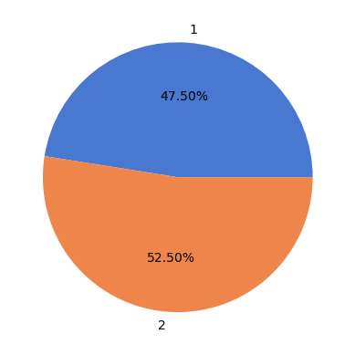

```python
plt.pie(df.groupby(["Season Number"])["Pitch Number"].count().values,labels=df.groupby(["Season Number"])["Pitch Number"].
    count().index,autopct="%.2f%%",colors=sns.color_palette("muted"));
```

### HOW MANY BRANDS PARTICIPATED IN EACH SEASON EXCLUDING NON TELECASTED PITCH?

```python
episodes.groupby(["Season Number"])["Pitch Number"].count()
```

```
Season Number
1    122
2    168
Name: Pitch Number, dtype: int64
```

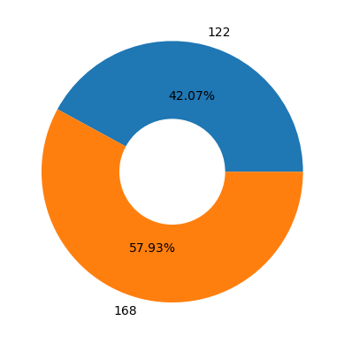

```python
plt.pie(episodes.groupby(["Season Number"])["Pitch Number"].count().values,labels=episodes.groupby(["Season Number"])
    ["Pitch Number"].count(), autopct="%.2f%%")
circle = plt.Circle( (0,0), 0.4, color='white')
p=plt.gcf()
p.gca().add_artist(circle);
```

1- Season 1 : 122 Entrepreneurs participated

2- Season 2 : 168 Entrepreneurs participated

### HOW MANY INDUSTRY IN OVERALL EPISODES?

```python
df["Industry"].value_counts()
```

```
Food                            82
Beauty/Fashion                  58
Manufacturing                   38
Services                        28
Technology/Software             26
Medical/Health                  23
Vehicles/Electrical Vehicles    13
Furnishing/Household            13
Education                        9
Sports                           7
Liquor/Beverages                 7
Animal/Pets                      5
Electronics                      4
Agriculture                      3
Hardware                         2
Entertainment                    2
Name: Industry, dtype: int64
```

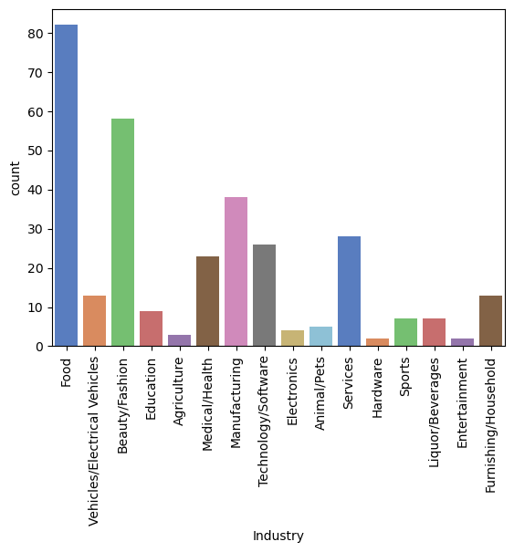

```python
sns.countplot(x="Industry",data=df,palette="muted")
plt.xticks(rotation=90);
```

Food industry participated the most in both the seasons

```python
df.groupby(["Season Number"])["Industry"].agg(["value_counts"])
```

| Season Number | Industry | value_counts |
| --- | --- | --- |
| 1 | Food | 41 |
|  | Beauty/Fashion | 27 |
|  | Manufacturing | 21 |
|  | Services | 13 |
|  | Technology/Software | 12 |
|  | Education | 9 |
|  | Medical/Health | 9 |
|  | Vehicles/Electrical Vehicles | 5 |
|  | Animal/Pets | 4 |
|  | Electronics | 3 |
|  | Agriculture | 2 |
|  | Hardware | 2 |
|  | Sports | 2 |
|  | Entertainment | 1 |
|  | Liquor/Beverages | 1 |
| 2 | Food | 41 |
|  | Beauty/Fashion | 31 |
|  | Manufacturing | 17 |
|  | Services | 15 |
|  | Medical/Health | 14 |
|  | Technology/Software | 14 |
|  | Furnishing/Household | 13 |
|  | Vehicles/Electrical Vehicles | 8 |
|  | Liquor/Beverages | 6 |
|  | Sports | 5 |
|  | Agriculture | 1 |
|  | Animal/Pets | 1 |
|  | Electronics | 1 |
|  | Entertainment | 1 |

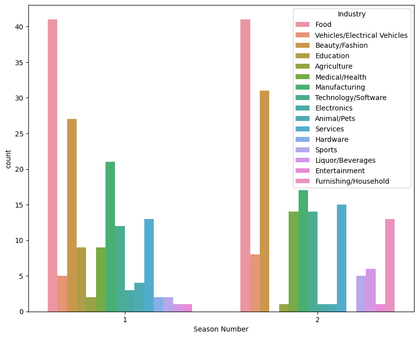

```python
plt.figure(figsize=(10,8))
sns.countplot(x="Season Number",data=df,hue="Industry");
```

```python
df["Industry"].value_counts()
```

```
Food                            82
Beauty/Fashion                  58
Manufacturing                   38
Services                        28
Technology/Software             26
Medical/Health                  23
Vehicles/Electrical Vehicles    13
Furnishing/Household            13
Education                        9
Sports                           7
Liquor/Beverages                 7
Animal/Pets                      5
Electronics                      4
Agriculture                      3
Hardware                         2
Entertainment                    2
Name: Industry, dtype: int64
```

### PIECHART OF 5 MOST EFFECTIVE AND LEAST EFFECTIVE INDUSTRIES PARTICIPATED

##### 5 most effective

```python
df["Industry"].value_counts()[0:5]
```

```
Food                   82
Beauty/Fashion         58
Manufacturing          38
Services               28
Technology/Software    26
Name: Industry, dtype: int64
```

```
 [Text(0.48874288971555274, 0.9854594805229139, 'Food'),
 [Text(0.2665870307539378, 0.5375233530124984, '35.34%'),
```

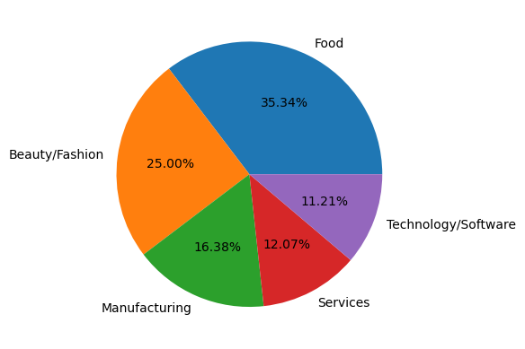

```python
plt.pie(df["Industry"].value_counts()[0:5].values,labels=df["Industry"].value_counts()[0:5].index, autopct="%.2f%%")
```

##### 5 least effective

```python
df["Industry"].value_counts().tail(5)
```

```
Animal/Pets      5
Electronics      4
Agriculture      3
Hardware         2
Entertainment    2
Name: Industry, dtype: int64
```

```
 [Text(0.6111272563215626, 0.9146165735327998, 'Animal/Pets'),
 [Text(0.33334213981176136, 0.4988817673815271, '31.25%'),
```

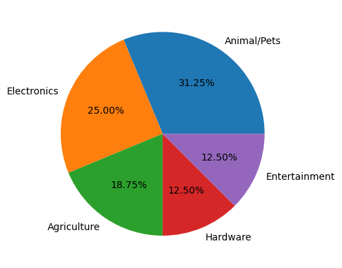

```python
plt.pie(df["Industry"].value_counts().tail(5).values,labels=df["Industry"].value_counts().tail(5).index, autopct="%.2f%%")
```

### GROUP ANALYSIS

##### WHICH SHOW FEATURED THE LARGEST CREW SIZE?

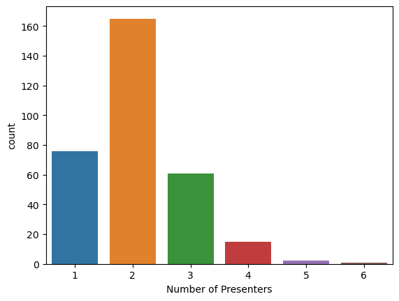

```python
sns.countplot(x="Number of Presenters",data=df)
```

We can see that just two people in each team participated to the fullest extent, with six people making up the largest single team.

```python
df[df["Number of Presenters"]==6]
```

|  | Season Number | Season Start | Season End | Episode Number | Episode Title | Pitch Number | Startup Name | Industry | Business Description | Number of Presenters | Male Presenters | Female Presenters | Transgender Presenters | Couple Presenters | Pitchers Average Age | Started in | Pitchers City | Pitchers State | Yearly Revenue | Monthly Sales | Gross Margin | Net Margin | Original Ask Amount | Original Offered Equity | Valuation Requested | Received Offer | Accepted Offer | Total Deal Amount | Total Deal Equity | … |
| --- | --- | --- | --- | --- | --- | --- | --- | --- | --- | --- | --- | --- | --- | --- | --- | --- | --- | --- | --- | --- | --- | --- | --- | --- | --- | --- | --- | --- | --- | --- |
| 87 | 1 | 20-Dec-21 | 4-Feb-22 | 27 | Investing In The Future Of India | 88 | AlisteTechnologies | Technology/Software | Automation Solutions | 6 | 6.0 | 0.0 | 0.0 | 0.0 | Young | 2020.0 | Noida | Uttar Pradesh | NaN | 7.5 | 40.0 | NaN | 60.0 | 5.0 | 1200.0 | 1 | 0.0 | NaN | NaN | … |

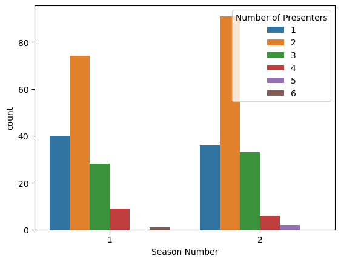

```python
sns.countplot(x="Season Number",hue="Number of Presenters",data=df)
```

1. There is no squad of five players in Season 1, and the maximum team size is 6.
2. The maximum team size in Season 2 is 5.